# Mixed DPs, participants 1 to 30

# Overview

The original dataset contains 1063 DPs produced by 30 participants. 78 out of 1063 do not include our target Basque lemma, and 44 do not include a Spanish DET (in 90% of these cases, the produced noun corresponds to a full Basque DP, i.e. ending with the suffix -a (sing) or -ak (pl)).

The final dataset contains 940 mixed DPs by 30 participants where the produced noun matches our target Basque lemma, and a Spanish DET is included.

Each participant is presented with 32 different images (i.e. 32 target lemmas). Sometimes they name an image more than once (with the same or a different DP), and sometimes the DP they use to name an image does not match the target experimental lemma. On average, each participant has produced 31 mixed DPs matching our experimental criteria.

We also exclude from the analysis plural DPs, since the focus of the study is gender assignment in singular DPs. Plural DPs account for less than 2% of the data (n=16).

| detNumber | n | proportion |
| --- | --- | --- |
| p | 16 | 0.0170213 |
| s | 924 | 0.9829787 |

Frequency of feminine/masculine DPs:

| detGender | n | proportion |
| --- | --- | --- |
| f | 485 | 0.5159574 |
| m | 455 | 0.4840426 |

Frequency of Spanish determiners used in the mixed DPs:

| det | detGender | n | proportion |
| --- | --- | --- | --- |
| la | f | 481 | 0.5117021 |
| el | m | 439 | 0.4670213 |
| los | m | 13 | 0.0138298 |
| las | f | 3 | 0.0031915 |
| del | m | 2 | 0.0021277 |
| un | m | 1 | 0.0010638 |
| una | f | 1 | 0.0010638 |

# Analogical gender

If the gender of the produced Spanish DET matches the gender of the produced Basque noun’s Spanish translation, we can infer that the employed strategy is analogical gender. How often do participants use analogical gender assignment? Overall = 0.6974184; however, important differences between groups.

| L_1 | how often analogical gender? | st_dev |
| --- | --- | --- |
| Basque | 0.5677399 | 0.0580932 |
| Spanish&Basque | 0.7620192 | 0.0964905 |
| Spanish | 0.8109864 | 0.1036802 |

Participants with L1=Spanish show the highest proportion of analogical gender, L1=Basque show the lowest, and L1=Basque&Spanish are in between, but closer to L1=Spanish. Statistically speaking, the main predictor of using the analogical criterion is whether the speaker has Spanish as an L1 or not (rather than whether they speak Basque as an L1 or not).

| is Spanish (one of) their L1? | how often analogical gender? | st_dev |
| --- | --- | --- |
| no | 0.5677399 | 0.0580932 |
| yes | 0.7965843 | 0.1012268 |

In the boxplot below we show how often each group of speakers use analogical gender. Each dot represent one participant, and they are grouped according to their L1. The L1=SB group overlaps with L1=S group, whereas the L1=B does not overlap. There is only one L1=B participant using the analogical criterion more than 65% (which resembles the behaviour of the L1=S/L1=SB relying the least on gender analogy). This participant (A11) is the only L1=B for whom both Basque *and* Spanish are dominant according to the sociolinguistic questionnaire.

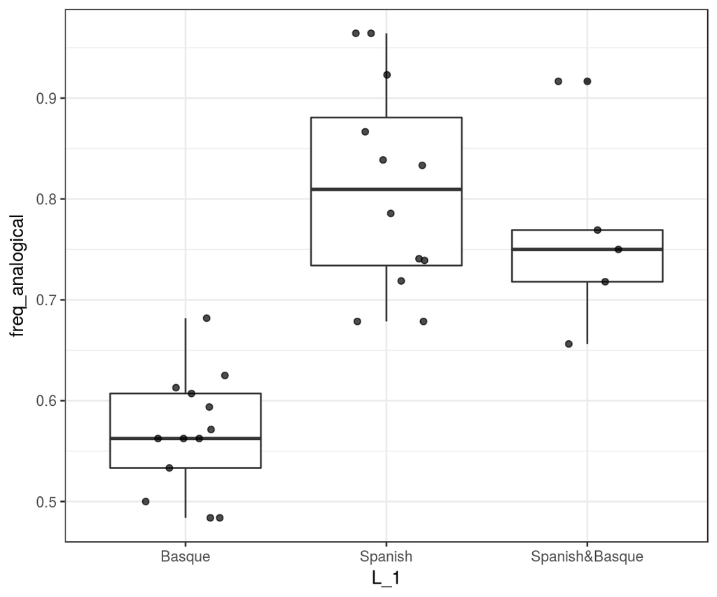

Below we plot the frequency of analogical gender, colour-coded according to whether the participant has Spanish as L1 or not. We observe this produces a bimodal distribution, meaning these two subsamples behave differently.

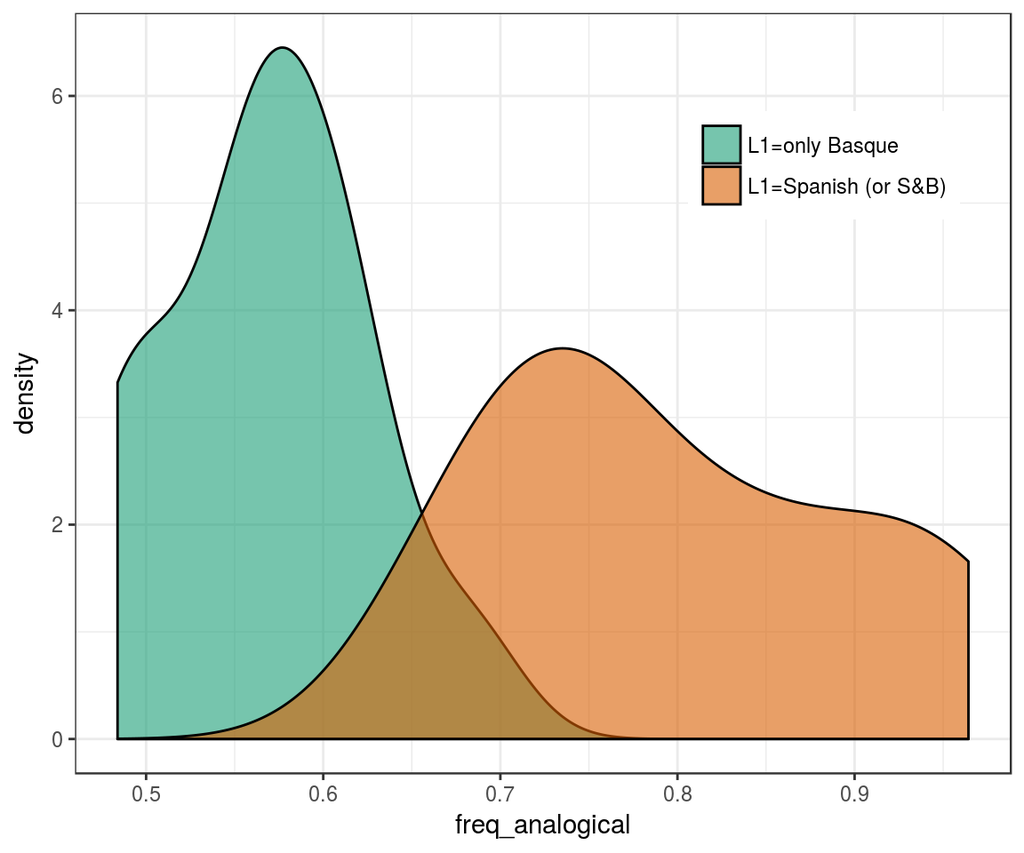

We confirm this by running a mixed generalized logistic model (glmer). Having Basque as one of the L1s decreases the likelihood of using analogical gender (see negative estimate: -0.34, p=0.1278), however, the effect of having Spanish as one of the L1s is much bigger, and statistically more robust (see positive estimate: 0.83, p=4.76e-05).

```
## Generalized linear mixed model fit by maximum likelihood (Laplace
##   Approximation) [glmerMod]
##  Family: binomial  ( logit )
## Formula: factor(analogical) ~ L1_B + L1_S + (1 | participant)
##    Data: d
##
##      AIC      BIC   logLik deviance df.resid
##   1093.5   1112.8   -542.7   1085.5      920
##
## Scaled residuals:
##     Min      1Q  Median      3Q     Max
## -2.0729 -1.1539  0.4824  0.8666  0.8666
##
## Random effects:
##  Groups      Name        Variance Std.Dev.
##  participant (Intercept) 0        0
## Number of obs: 924, groups:  participant, 30
##
## Fixed effects:
##             Estimate Std. Error z value Pr(>|z|)
## (Intercept)   0.6298     0.2464   2.556   0.0106 *
## L1_B         -0.3435     0.2256  -1.523   0.1278
## L1_S          0.8281     0.2036   4.067 4.76e-05 ***
## ---
## Signif. codes:  0 '***' 0.001 '**' 0.01 '*' 0.05 '.' 0.1 ' ' 1
##
## Correlation of Fixed Effects:
##      (Intr) L1_B
## L1_B -0.915
## L1_S -0.826  0.688
```

# Main strategy used by participants

|  | analogical | analogical/phonnoun | defaultf | defaultm | phonlemma | phonlemma/phonnoun | phonnoun |
| --- | --- | --- | --- | --- | --- | --- | --- |
| Basque | 2 | 1 | 2 | 1 | 3 | 1 | 3 |
| Spanish | 9 | 0 | 0 | 0 | 2 | 0 | 1 |
| Spanish&Basque | 2 | 2 | 0 | 1 | 0 | 0 | 0 |

# Phonology-driven gender assignment

How does the ending of the Basque noun affect the gender assignment? As noted before, the phonological strategy is dominant for L1=B, but is also used by L1=S (in this section, L1=SB is included under L1=S). The plot below shows the frequency of a f(eminine) or m(asculine) DET in mixed DPs ending in each of the four endings under study: a, i, n, o. The upper panel includes the results for participants who don’t have Spanish as one of their L1s, and the lower panel participants those who do.

L1=B (upper panel) indicates that nouns ending in -a (whether part of the lemma or a suffix) trigger a fem DET. The other three endings (i, n, o), trigger a masc DET. In the case of -i, this occurs 100% of the times.

L1=S (lower panel) shows a different pattern. Even if the analogical strategy is dominant for this group, nouns ending in -i and -o follow a phonological strategy, as they trigger predominantly a masc DET. Nouns ending in -a and -n, however, do not follow a phonological strategy, as they trigger both masc and fem DET at chance level. Here, the main strategy for nouns ending in -a and -n is analogical and not phonological.

Note, however, that the fact that the DPs conform to the phonological strategy (e.g. for nouns ending in -i) does not exclude that they *also* follow the analogical strategy, since the two criteria can be correlated: e.g. *el begi* (el_m ojo_m; the_m eye_m). This is left for further analysis.

Check whether the phonological ending of the word (i.e. *not* of the lemma) triggers preferentially a gender (f/m). It always does for L1B (a=f, i/n/o=m), it does only sometimes for L1S (i/o=m).

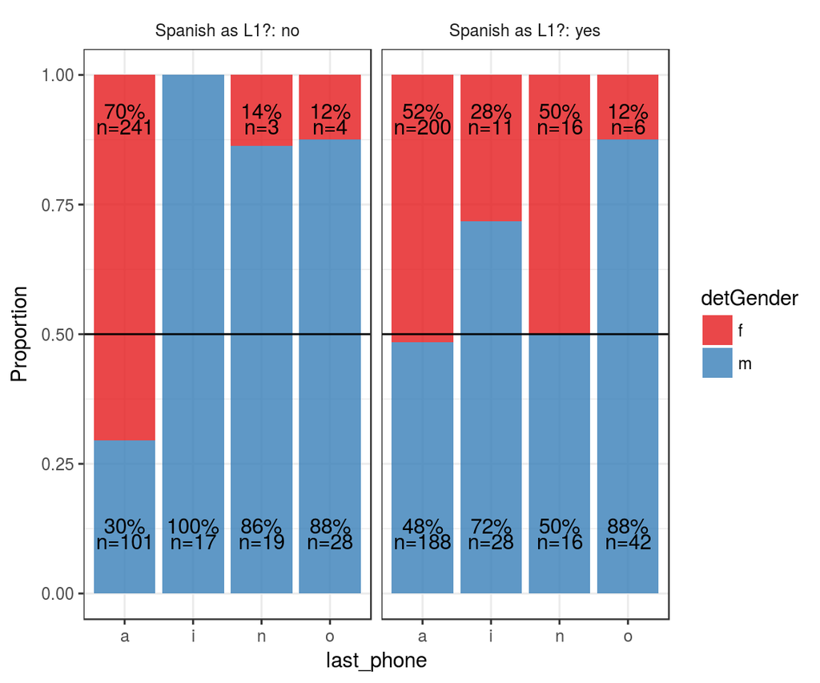

Proportion analogical:

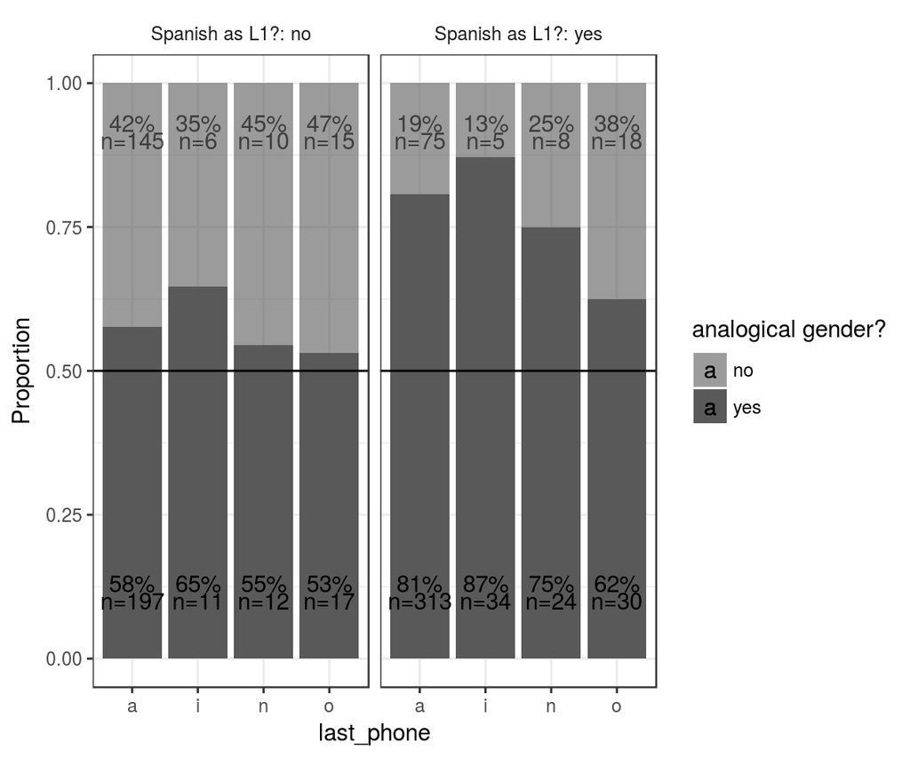

# Side note on -a ending

1/4 of the images (n=8) correspond to a Basque target lemma ending in -a. Almost all DPs including these lemmas also end in -a, except for 3 cases where the plural ending -ak is used.

| last_phone | n | proportion |
| --- | --- | --- |
| a | 222 | 0.9866667 |
| k | 3 | 0.0133333 |

The remaining 3/4 of the target stimuli (n=24) correspond to a target lemma where the final phoneme is not /a/. However, (…) citation forms in Basque include the DET -a. In the experiment, when participants use a mixed DP with a lemma not ending in -a, they include the -a suffix most of the times (73%).

| last_phone | n | proportion |
| --- | --- | --- |
| a | 508 | 0.7267525 |
| i | 56 | 0.0801144 |
| n | 54 | 0.0772532 |
| o | 80 | 0.1144492 |
| u | 1 | 0.0014306 |

Side note (maybe for future experiments). Adding the suffix -a increases the number of syllables of the word by +1. If the Basque lemma employed in the DP is 3-syllables long, it is much less likely that the suffix -a is added: participants add the suffix -a 80% of the times for 2-syllable lemmas (419/526), but only 51% of the times for 3-syllable lemmas (89/173). A chi-squared test of independence reveals this is statistically significant ($\chi^2$=39.544, df=1, p=3.208e-10). Possible prosodic explanation.

| lemma_syllables | a_suffix_added | n | proportion |
| --- | --- | --- | --- |
| 2 | 0 | 107 | 0.2034221 |
| 2 | 1 | 419 | 0.7965779 |
| 3 | 0 | 84 | 0.4855491 |
| 3 | 1 | 89 | 0.5144509 |

```
##
##  Pearson's Chi-squared test with Yates' continuity correction
##
## data:  .
## X-squared = 39.544, df = 1, p-value = 3.208e-10
```

# Nouns with -a ending

Here, L1_S stands for: acquired Spanish *before* the age of 4 (sometimes Basque too); and L1_B stands for: acquired Spanish *after* the age of 4.

## Primary strategy

The majority of the nouns in the mixed DPs end in -a (whether part of lemma or not). 82% for L1_B, 76% for L1_S.

| L1_S | last_a | n | p |
| --- | --- | --- | --- |
| 0 | 1 | 342 | 0.8240964 |
| 1 | 1 | 388 | 0.7622790 |

Which is the main strategy for nouns ending in -a? If L1_S: analogical=80% (vs L1_B: analogical=58%) If L1_B: default_f/word-ending=70% (vs L1_S=51%)

gender by analogy

| L1_S | mean(p) | sum(n) |
| --- | --- | --- |
| 0 | 0.5758410 | 197 |
| 1 | 0.8052555 | 313 |

gender by lemma ending

| L1_S | mean(p) | sum(n) |
| --- | --- | --- |
| 0 | 0.4672486 | 166 |
| 1 | 0.5526140 | 217 |

gender by default_f (or word ending, which is always -a in this case)

| L1_S | mean(p) | sum(n) |
| --- | --- | --- |
| 0 | 0.6968928 | 241 |
| 1 | 0.5063290 | 200 |

## Secondary strategy

What about the residuals? i.e. for L1_S: analogical=0 (20% of -a ending words) i.e. for L1_B: default_f=0 (30% of -a ending words)

residuals of L1_S. does the 20% not explained by analogy follow the lemma-ending gender? pretty much: 70%.

| L1_S | last_phone_lemma | phon_lemma | n | p |
| --- | --- | --- | --- | --- |
| 1 | n | 1 | 11 | 0.6111111 |
| 1 | o | 1 | 13 | 0.6190476 |
| 1 | i | 1 | 10 | 0.7692308 |
| 1 | a | 1 | 18 | 0.7826087 |

```
## # A tibble: 1 x 3
##    L1_S `mean(p)` `sum(n)`
##   <dbl>     <dbl>    <int>
## 1     1     0.695       52
```

residuals of L1_S. does the 20% not explained by analogy follow the default_f? not really: 45%

| L1_S | last_phone_lemma | default_f | n | p |
| --- | --- | --- | --- | --- |
| 1 | i | 1 | 3 | 0.2307692 |
| 1 | o | 1 | 8 | 0.3809524 |
| 1 | n | 1 | 7 | 0.3888889 |
| 1 | a | 1 | 18 | 0.7826087 |

```
## # A tibble: 1 x 2
##    L1_S `mean(p)`
##   <dbl>     <dbl>
## 1     1     0.446
```

residuals of L1_B. does the 30% not explained by default_f/word-ending follow the lemma-ending gender? yes! 100%

| L1_S | last_phone_lemma | phon_lemma | n | p |
| --- | --- | --- | --- | --- |
| 0 | a | 0 | 17 | 1 |
| 0 | i | 1 | 29 | 1 |
| 0 | n | 1 | 23 | 1 |
| 0 | o | 1 | 32 | 1 |

residuals of L1_B. final check. does the 30% not explained by default_f/word-ending follow the analogical gender? not really: 62%

```
## # A tibble: 1 x 2
##    L1_S `mean(p)`
##   <dbl>     <dbl>
## 1     0     0.624
```

## Summary

For L1_S, a total 388 nouns end in -a. 80% of those (n=313) follow the analogical gender. Of the remaining 20%, most (70%, n=52) follow the lemma-ending gender. These two strategies account for 94% (n=365) of the DPs with -a ending nouns for L1_S.

For L1_B, a total 342 nouns end in -a. 70% of those (n=241) follow the default_f or noun-ending gender (they are equivalent here). Of the remaining 30%, *all* (100%, n=101) follow lemma-ending gender. These two strategies account for 100% (n=342) of the DPs with -a ending nouns for L1_B.

Using 4 criteria, we can account for the gender of 97% of the mixed DPs. These are the 23 cases where the criteria fail to explain the gender assignment:

|  | participant | trial | det | noun | lemma | target_lemma | comments | L1 | area |
| --- | --- | --- | --- | --- | --- | --- | --- | --- | --- |
| 1 | 10 | 30 | la | komuna | komun | komun | Rep1 | S | Donostia |
| 2 | 2 | 4 | el | ur-tanta | ur-tanta | tanta | synonyme (same phon. Ending) | S | Iruñerria |
| 3 | 2 | 13 | la | mokoa | moko | moko | Rep0 | S | Iruñerria |
| 4 | 3 | 32 | el | gona | gona | gona |  | SB | Iruñerria |
| 5 | 4 | 25 | la | begia | begi | malko | que tiene malkoa | S | Iruñerria |
| 6 | 5 | 5 | la | mokoa | moko | moko |  | S | Iruñerria |
| 7 | 5 | 12 | la | lepoa | lepo | lepo |  | S | Iruñerria |
| 8 | 5 | 28 | la | komuna | komun | komun |  | S | Iruñerria |
| 9 | 6 | 5 | la | mokoa | moko | moko |  | S | Iruñerria |
| 10 | A1 | 13 | la | kirtena | kirten | kirten | Rep1 | SB | Basauri |

[output cut: 13 more lines]

Hence, so far, to assign the gender to a Basque lemma, generally, add an -a. Then:

If acquired Spanish before age 4:

1. use analogical gender,
2. use lemma-ending prototypical gender.

If acquired Spanish after age 4:

1. use feminine (because it’s the default, or because word ends in -a, cannot disentangle),
2. use lemma-ending prototypical gender.

To do:

- Which factors determine the use of the primary or secondary strategy?
- Which factors determine whether an -a is added to the noun or not? (so far we only know that the general rule is to add an -a, and that this is particularly true for bisyllabic lemmas, but less so for trisyllabic lemmas.)
- Which are the main strategies for nouns where the suffix -a has *not* been added? (so far we know that the phonological ending of the noun is the primary strategy for L1_B, and that the analogical strategy is the primary one for L1_S.)